# Final Project Report - Kubernetes

## Unstructured data management/analytics procedures - Secondary dataset: issues_df

- Create corpus and tokens
- Keyword-in-contexts on words that we are not sure if they are meaningful or just stop words
- Automatic detection of compound tokens
- Constructing a document-feature matrix
- Construct a FCM
- Biterm Topic Model (BTM)

```r
# Create Corpus and tokens, remove stopwords
issues_corp <- corpus(issues_df)

issue_toks <- tokens(
  issues_corp,
  remove_punct = TRUE,
  remove_numbers = TRUE,
  remove_symbols = TRUE,
  remove_url = TRUE,
  split_hyphens = FALSE)

myStopWords = c(stopwords("en"),'fix','kubernetes','use','error',
          'make','automated', 'cherry' ,'pick','test','tests',
          'issue','issues', preposition,"#\\n",'suuport','using','really','something','may',
          'enough','to','null','true','false','fail','failed','k8s','main','please','etc',
          'can','ready','isstd','occurred','pr','index','isutc','specifically','br','k8s.io',
          'src','github.com','_output','info','go','n','nil','s','LGTM','lgtm','now','eventually',
          'f','close','open','send','process','feedback','title','instructions','assign','details')

toks_nostop <- tokens_remove(
  issue_toks, pattern = myStopWords)
toks_nostop
```

```
## Tokens consisting of 104,909 documents and 6 docvars.
## 995216325 :
## [1] "#104467"  "check"    "headless" "trying"   "release"
##
## 995215019 :
## [1] "Question" "vendor"   "runc"
##
## 995204229 :
## [1] "#104467"  "check"    "headless" "trying"   "release"
##
## 995201053 :
## [1] "#104467"  "check"    "headless" "trying"   "release"
##
## 995199752 :
## [1] "MERGE"   "Testing" "pod"     "hash"    "change"  "due"     "content"
## [8] "change"
##
## 995194963 :
## [1] "Update"          "debian-iptables" "CVE"             "fixes"
##
## [ reached max_ndoc ... 104,903 more documents ]
```

```r
# Keyword-in-contexts on words that we are not sure if they are meaningful or just stop words.
kw_add <- kwic(toks_nostop, pattern = "add", window = 2)
head(kw_add)%>%
  kbl() %>%
  kable_styling()
```

| docname | from | to | pre | keyword | post | pattern |
| --- | --- | --- | --- | --- | --- | --- |
| 994702077 | 2 | 2 | #103764 | Add | case pkg | add |
| 994695242 | 2 | 2 | #103764 | Add | case pkg | add |
| 994681286 | 2 | 2 | #103764 | Add | case pkg | add |
| 993635926 | 2 | 2 | #104919 | Add | recreating static | add |
| 993604712 | 2 | 2 | WIP | Add | mTLS default | add |
| 993582285 | 1 | 1 |  | Add | e2e recreating | add |

```r
kw_remove <- kwic(toks_nostop, pattern = "remove", window = 2)
head(kw_remove)%>%
  kbl() %>%
  kable_styling()
```

| docname | from | to | pre | keyword | post | pattern |
| --- | --- | --- | --- | --- | --- | --- |
| 994972721 | 1 | 1 |  | remove | duplicate LB | remove |
| 994873700 | 1 | 1 |  | remove | invalid check | remove |
| 993190583 | 1 | 1 |  | Remove | StorageObjectInUseProtection feature | remove |
| 993117626 | 3 | 3 | WIP kubelet | Remove | deprecated flag | remove |
| 992646350 | 1 | 1 |  | Remove | functionality deprecated | remove |
| 991106433 | 6 | 6 | DeltaFIFO.Replace used | remove |  | remove |

It is noticeable that there are meaningful words after add and remove. So, we decided to keep add and remove.

```r
#Automatic detection of compound tokens
compound_toks <- textstat_collocations(toks_nostop, min_count = 10)
head(compound_toks, 15)%>%
  kbl() %>%
  kable_styling()
```

| collocation | count | count_nested | length | lambda | z |
| --- | --- | --- | --- | --- | --- |
| broken run | 899 | 0 | 2 | 6.633647 | 103.43432 |
| cloud provider | 553 | 0 | 2 | 7.431181 | 88.23081 |
| e2e suite | 912 | 0 | 2 | 5.509866 | 88.19716 |
| azure disk | 299 | 0 | 2 | 5.890562 | 70.54798 |
| kubectl get | 448 | 0 | 2 | 3.942811 | 64.89847 |
| API server | 289 | 0 | 2 | 4.608162 | 63.32825 |
| upstream release | 508 | 0 | 2 | 8.667258 | 61.91081 |
| golint failures | 188 | 0 | 2 | 6.459021 | 61.51382 |
| failure cluster | 294 | 0 | 2 | 4.590996 | 61.34786 |
| getting started | 173 | 0 | 2 | 7.667967 | 58.17825 |
| race condition | 147 | 0 | 2 | 6.946294 | 57.10184 |
| remove unused | 312 | 0 | 2 | 5.260989 | 55.81690 |
| data race | 136 | 0 | 2 | 6.728283 | 55.13052 |
| builds jobs | 265 | 0 | 2 | 8.708513 | 54.81283 |
| e2e flake | 300 | 0 | 2 | 4.340084 | 54.61007 |

```r
toks_comp <- tokens_compound(
  toks_nostop, pattern = compound_toks[compound_toks$z > 100])
```

```r
#Constructing a document-feature matrix
issues_dfmat <- dfm(toks_comp, tolower = TRUE) %>%
   dfm_trim(min_termfreq = 5, min_docfreq = 10)

#identify top issues
topfeatures(issues_dfmat, 20)%>%
  kbl() %>%
  kable_styling()
```

|  | x |
| --- | --- |
| add | 9354 |
| e2e | 6533 |
| kubectl | 5476 |
| pod | 5081 |
| update | 4858 |
| kubelet | 4789 |
| remove | 4159 |
| node | 4056 |
| api | 3280 |
| support | 3223 |
| pods | 3222 |
| cluster | 2972 |
| volume | 2545 |
| service | 2322 |
| kubeadm | 2305 |
| pkg | 2166 |
| controller | 2165 |
| container | 2010 |
| version | 1931 |
| create | 1883 |

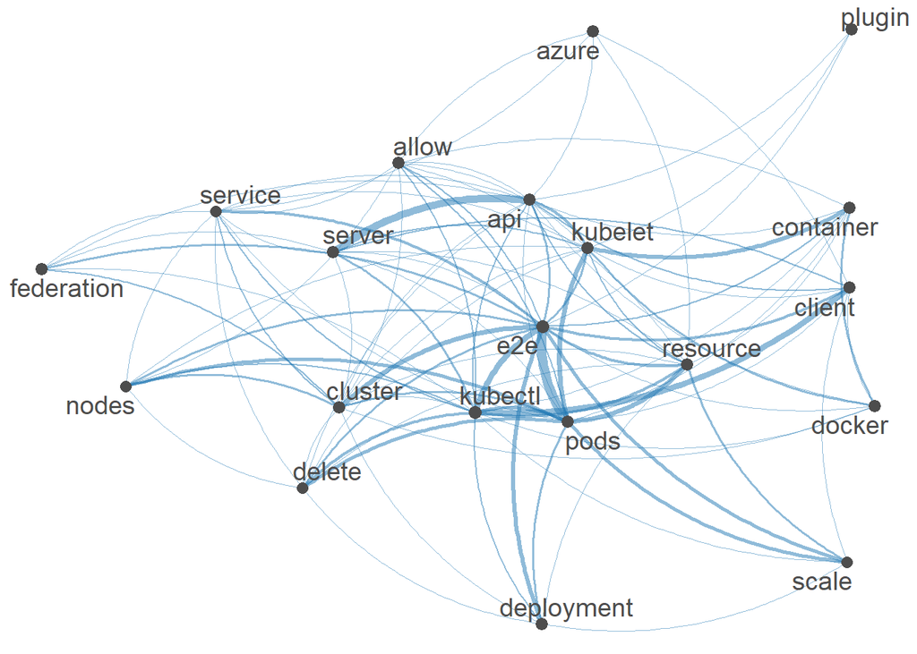

```r
#Construct a FCM
issues_fcmat <- fcm(issues_dfmat)
feat <- names(topfeatures(issues_fcmat, 20))
fcmat_select <- fcm_select(issues_fcmat, pattern = feat, selection = "keep")
size <- log(colSums(dfm_select(issues_fcmat, feat, selection = "keep")))
set.seed(123)
textplot_network(fcmat_select, min_freq = 0.5, vertex_size = size/max(size)*3)
```

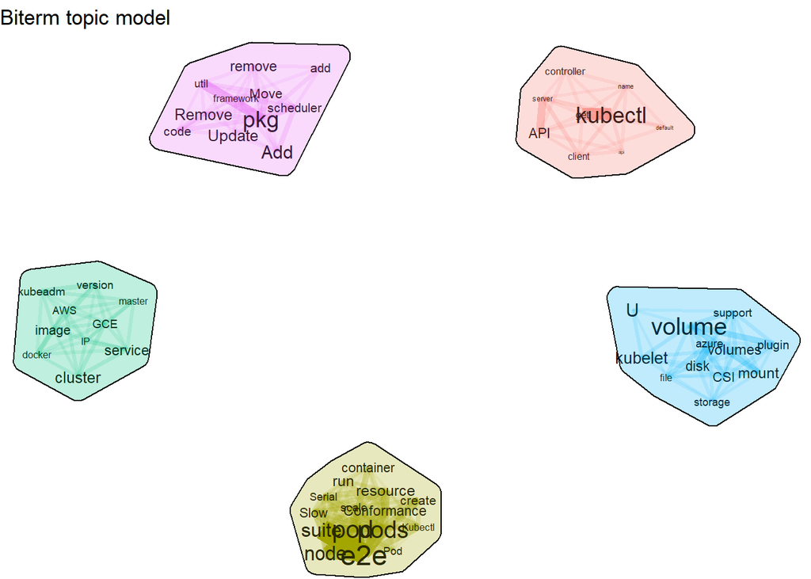

```r
#BTM
as.data.frame.tokens <- function(x) {
  tibble(
    doc_id = rep(names(x), lengths(x)),
    tokens = unlist(x, use.names = FALSE)
  )
}
issues_title_btm_df <- as.data.frame.tokens(toks_nostop)
library(udpipe)
library(BTM)
issues_tmod_btm <- BTM(issues_title_btm_df, k = 5)
library(textplot)
library(ggraph)
plot(issues_tmod_btm, top_n = 15)
```

## Unstructured data management/analytics procedures - Primary dataset: kubernetes_timeline

- Join Primary dataset with Secondary dataset on issue_id
- Select only comments with the titles relating to the main issues identified above: e2e,add,update,kubelet,pod,node,cluster,api,kubeadm,gce,container,scheduler,aws,volume,docker
- Create Corpus and tokens
- Construct a document-feature matrix
- Construct a FCM
- Relative frequency analysis (keyness) (open vs closed issues, before 2017 and after 2017)
- Correlated topic model after 2017
- Structure topic model after 2017
- Keyword Assisted Topic Model (Base) after 2017

```r
#Join Primary dataset with Secondary dataset on issue_id
join <-merge(x=comments_df,y=issues_df,by="issue_id",all.x=TRUE)
#Select only comments with the titles relating to the main issues identified above
join_filter = dplyr::filter(join, grepl('e2e|add|update|kubelet|pod*|node*|cluster|api*|kubeadm|
                                                  gce|container|scheduler|aws|volume|docker', text.y))
#Create Corpus and tokens

k8s_corp <- corpus(join_filter, docid_field = "timeline_id", text_field = "text.x")
k8s_toks <- tokens(
  k8s_corp,
  remove_punct = TRUE,
  remove_numbers = TRUE,
  remove_symbols = TRUE,
  remove_url = TRUE,
  split_hyphens = FALSE)

k8s_toks_nostop <- tokens_remove(
  k8s_toks, pattern = myStopWords)
#Automatic detection of compound tokens
k8s_tstat_col <- textstat_collocations(k8s_toks_nostop, min_count = 10)
k8s_toks_comp <- tokens_compound(
  k8s_toks_nostop, pattern = k8s_tstat_col[k8s_tstat_col$z > 100])
#Construct a document-feature matrix
k8s_dfmat <- dfm(k8s_toks_comp)
k8s_dfmat <- dfm(k8s_toks_comp, tolower = TRUE) %>%
  dfm_trim(min_termfreq = 5, min_docfreq = 10)

topfeatures(k8s_dfmat, 30)%>%
  kbl() %>%
  kable_styling()
```

|  | x |
| --- | --- |
| pod | 77056 |
| pods | 65669 |
| e2e_suite_dockerized_e2e | 48548 |
| cluster | 45589 |
| -1 | 43138 |
| node | 42122 |
| jar_usr_share_cassandra_lib | 41850 |
| kubelet | 41138 |
| utc | 39540 |
| think | 30468 |
| timed_waiting_condition_timed_waiting_condition_dockerized_e2e_framework_framework.go | 29058 |
| namespace | 28338 |
| exit_status | 28139 |
| somegroup | 27874 |
| name | 27667 |
| container | 26684 |
| dockerized_e2e | 25432 |
| one | 25400 |
| running | 25295 |
| just | 24806 |
| com.hazelcast.system | 24591 |
| get | 24571 |
| need | 23987 |
| status | 23643 |
| code | 23331 |
| thanks | 22949 |
| also | 22796 |
| c.h.instance.defaultaddresspicker | 21075 |
| see | 20981 |
| e2e_suite_dockerized_e2e_framework_framework.go_expected_errors.errorstring | 20447 |

```r
#Construct a FCM
k8s_fcmat <- fcm(k8s_dfmat)
topfeatures(k8s_fcmat, 30)%>%
  kbl() %>%
  kable_styling()
```

|  | x |
| --- | --- |
| jar_usr_share_cassandra_lib | 62259435 |
| ninfo_initializing | 23189961 |
| running_status_pod | 13720705 |
| gcr.io_google_containers | 13556279 |
| -xx | 12715701 |
| threshold_enabled | 11118296 |
| usr_share_cassandra_lib | 10674024 |
| run_httpurlconnection.java | 9938379 |
| e2e_suite_dockerized_e2e | 9814747 |
| timed_waiting_condition_timed_waiting_condition_dockerized_e2e_framework_framework.go | 9321224 |
| dockerized_e2e_framework_framework.go | 8835086 |
| dockerized_e2e | 8776158 |
| release.jar | 8489841 |
| memtable | 8407540 |
| utc | 8064643 |
| e2e_suite_dockerized_e2e_framework_framework.go_expected_errors.errorstring | 7184630 |
| nwaiting | 6853597 |
| configuration_unable_start_server_see_log | 6590259 |
| -0700_pdt | 6302183 |
| examples.go_expected_errors.errorstring | 5824998 |
| serviceaccounts_fieldselector_metadata.name | 5811186 |
| somegroup_starting | 5745915 |
| somegroup_starting_partition_threads | 5707956 |
| somegroup_configured_hazelcast_serialization_version | 5694139 |
| local_somegroup_picked_socket | 5680322 |
| back_default_profiles_default | 5675793 |
| com.github.pires.hazelcast.application_active_profile_set_falling | 5661682 |
| somegroup_starting_generic_threads_dedicated_priority_tasks | 5654233 |
| springapplication.java_spring-boot-1.4.0 | 5651258 |
| pod | 5650551 |

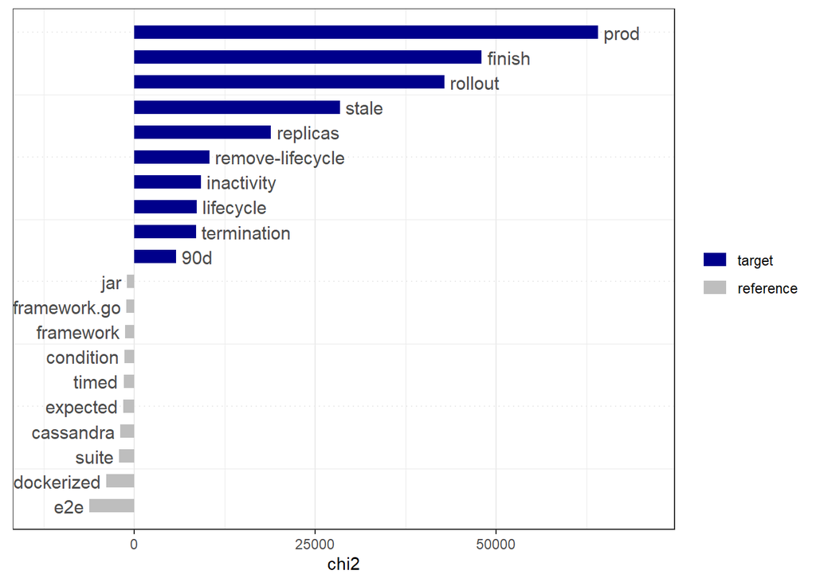

```r
#Relative frequency analysis (keyness) - Open vs. Closed issues
k8s_dfmat_single <- dfm(k8s_toks_nostop, tolower = TRUE) %>%
  dfm_trim(min_termfreq = 5, min_docfreq = 10)
k8s_tstat_key <- textstat_keyness(
  k8s_dfmat_single, target = k8s_dfmat_single$state == 'open')
textplot_keyness(k8s_tstat_key, n=10, min_count = 20)
```

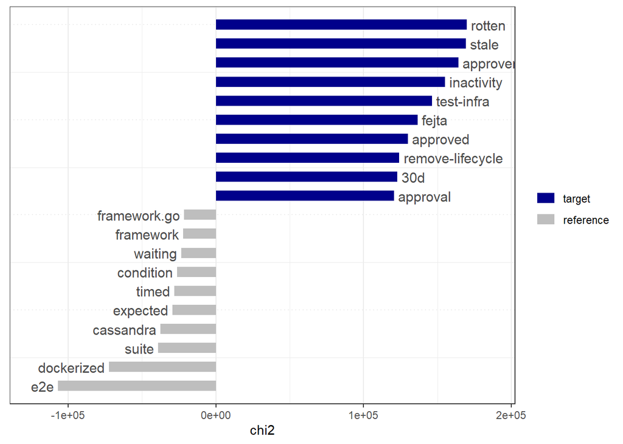

```r
#Relative frequency analysis (keyness) - <= 2017 vs > 2017
k8s_tstat_key_year <- textstat_keyness(
  k8s_dfmat_single, target = k8s_dfmat_single$year.x > 2017)
textplot_keyness(k8s_tstat_key_year, n=10, min_count = 20)
```

```r
#DFM after 2017
combined_df_17_new <- merge(x = comments_df, y = issues_df,
                            by = "issue_id", all.x = TRUE) %>%
  filter(year.x > 2017)

combined_df_17_new <- dplyr::filter(combined_df_17_new, grepl('e2e|add|update|kubelet|pod*|node*|cluster|api*|kubeadm|
      gce|container|scheduler|aws|volume|docker', text.y))

k8s_corp_new <- corpus(combined_df_17_new, docid_field = "timeline_id", text_field = "text.x")

k8s_toks_new <- tokens(
  k8s_corp_new,
  remove_punct = TRUE,
  remove_numbers = TRUE,
  remove_symbols = TRUE,
  remove_url = TRUE,
  split_hyphens = FALSE)


toks_nostop_17_new <- tokens_remove(
  k8s_toks_new, pattern = myStopWords)

compound_toks_17_new <- textstat_collocations(toks_nostop_17_new, min_count = 10)

toks_comp_17_new <- tokens_compound(
  toks_nostop_17_new, pattern = compound_toks_17_new[compound_toks_17_new$z > 100])

k8s_dfmat_new <- dfm(k8s_toks_new, tolower = TRUE) %>%
  dfm_remove(c(stopwords("en"), myStopWords)) %>%
  dfm_trim(min_termfreq = 5, min_docfreq = 10)
topfeatures(k8s_dfmat_new, 20)%>%
  kbl() %>%
  kable_styling()
```

|  | x |
| --- | --- |
| approved | 40578 |
| stale | 40469 |
| comment | 40315 |
| approval | 39750 |
| test-infra | 39642 |
| approvers | 38233 |
| approve | 34546 |
| inactivity | 34066 |
| cancel | 33765 |
| rotten | 33385 |
| writing | 28936 |
| bot | 28819 |
| href | 27270 |
| fejta | 27037 |
| 30d | 26553 |
| remove-lifecycle | 26259 |
| commands | 23744 |
| file | 23436 |
| retest | 23147 |
| full | 22640 |

```r
#CTM after 2017
library(stm)
stm_k8s_dfmat_new <- quanteda::convert(k8s_dfmat_new, to = "stm")

out_new <- prepDocuments(stm_k8s_dfmat_new$documents,
                     stm_k8s_dfmat_new$vocab, stm_k8s_dfmat_new$meta)


k8s_tmod_ctm_new <- stm(out_new$documents, out_new$vocab, K = 5,
                   seed = 123, emtol = 1e-3,
                   max.em.its = 2)
```

```
## Beginning Spectral Initialization
##   Calculating the gram matrix...
##   Using only 10000 most frequent terms during initialization...
##   Finding anchor words...
##      .....
##   Recovering initialization...
##      ....................................................................................................
## Initialization complete.
## ....................................................................................................
## Completed E-Step (38 seconds).
## Completed M-Step.
## Completing Iteration 1 (approx. per word bound = -7.267)
## ....................................................................................................
## Completed E-Step (36 seconds).
## Completed M-Step.
## Model Terminated Before Convergence Reached
```

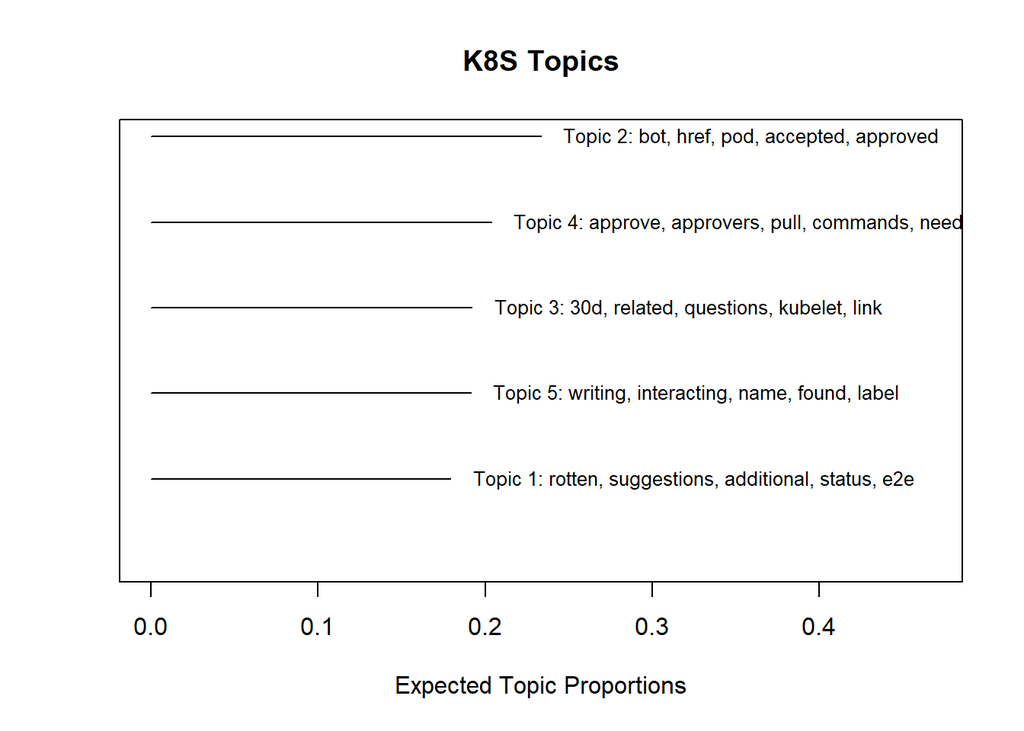

```r
plot(k8s_tmod_ctm_new, type = "summary", n = 5, labeltype = "frex",
     main = "K8S Topics", text.cex = 0.8)
```

```r
#Semantic coherence and exclusivity

topicQuality(k8s_tmod_ctm_new, out_new$documents)
```

```
## [1] -174.3989 -278.6742 -213.8292 -115.0415 -155.9849
## [1] 9.580032 9.781494 9.576087 9.868484 9.427639
```

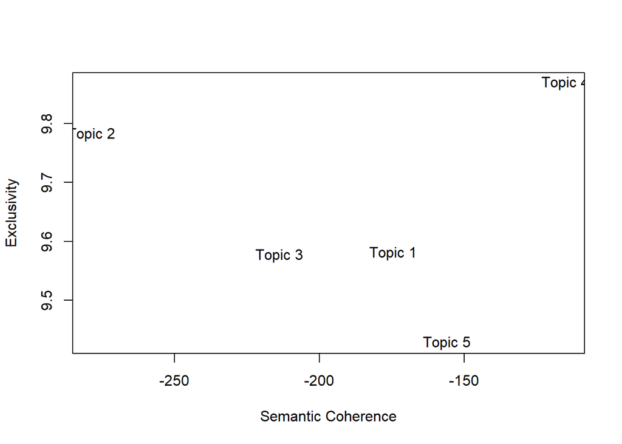

```r
#STM after 2017
k8s_tmob_stm_new <- stm(out_new$documents, out_new$vocab, K = 5,
                    prevalence = ~s(year.x), data = out_new$meta,
                    init.type = "Spectral", seed = 123, max.em.its = 2)
```

```
## Beginning Spectral Initialization
##   Calculating the gram matrix...
##   Using only 10000 most frequent terms during initialization...
##   Finding anchor words...
##      .....
##   Recovering initialization...
##      ....................................................................................................
## Initialization complete.
## ....................................................................................................
## Completed E-Step (37 seconds).
## Completed M-Step.
## Completing Iteration 1 (approx. per word bound = -7.267)
## ....................................................................................................
## Completed E-Step (36 seconds).
## Completed M-Step.
## Model Terminated Before Convergence Reached
```

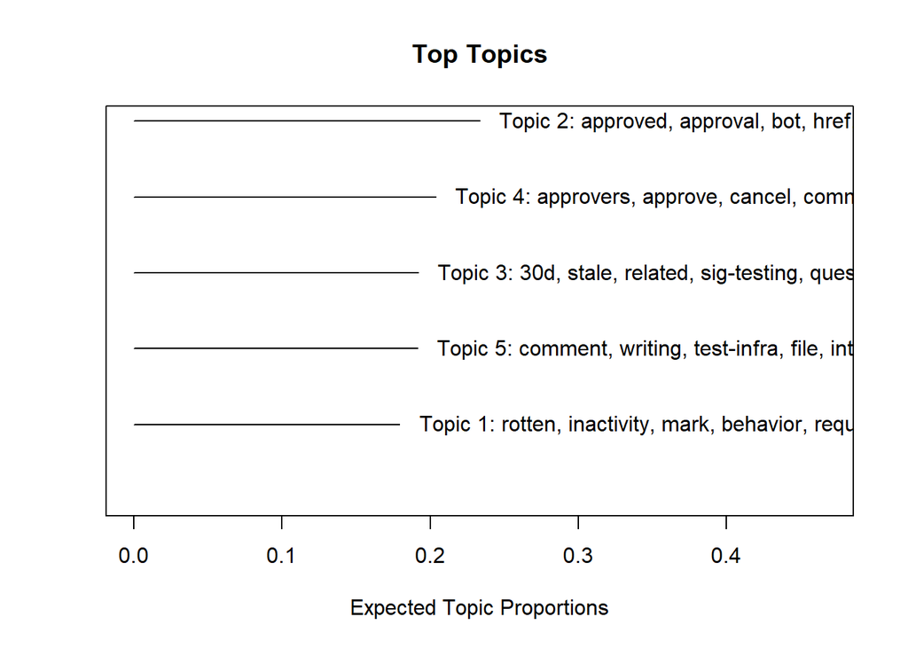

```r
plot(k8s_tmob_stm_new, type = "summary", n = 5)
```

```r
#Semantic coherence and exclusivity

topicQuality(k8s_tmob_stm_new, out_new$documents)
```

```
## [1] -174.3989 -278.6742 -213.8292 -115.0415 -155.9849
## [1] 9.580032 9.781494 9.576160 9.868484 9.427497
```

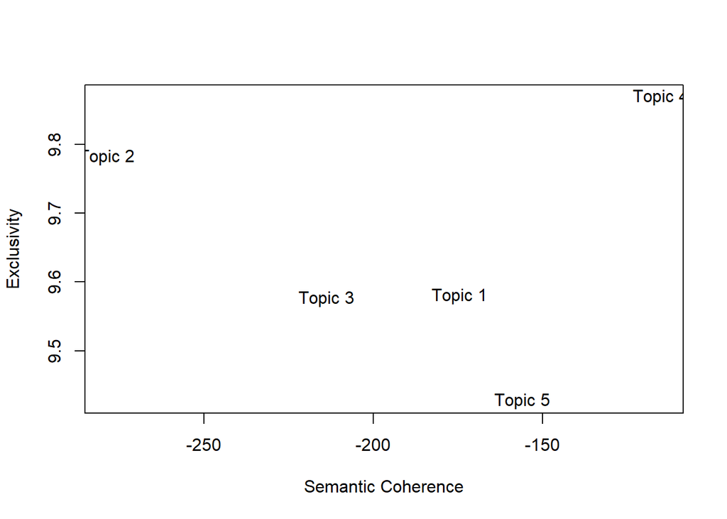

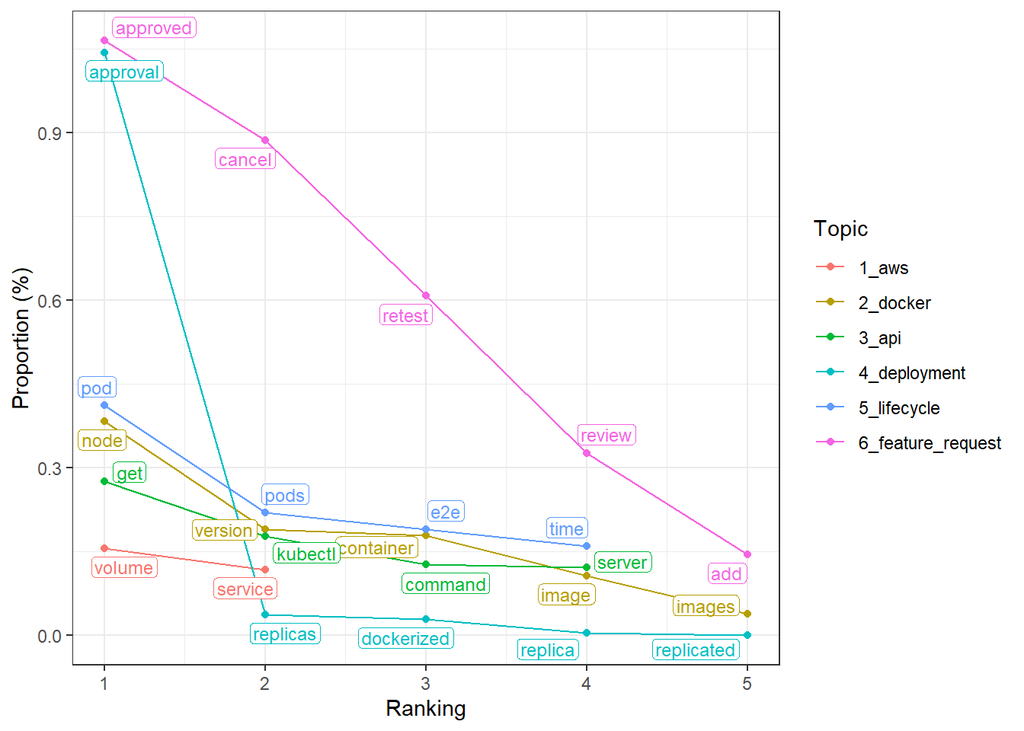

```r
#Keyword Assisted Topic Model (Base) after 2017
library(keyATM)
keyATM_docs <- keyATM_read(texts = k8s_dfmat_new)

k8s_key_list = list(
  aws = c("volume", "service"),
  docker = c("container", "image", "images", "node", "version"),
  api = c("get", "server", "command", "kubectl"),
  deployment = c("replica", "replicas", "replicated", "approval", "dockerized"),
  lifecycle = c("pod", "pods", "time", "e2e"),
  feature_request = c("retest", "review", "cancel", "add", "approved", "details")
)

# check topic proportion
k8s_key_viz <- visualize_keywords(docs = keyATM_docs, keywords = k8s_key_list)
k8s_key_viz
```

```r
# keyatm base after 2017
k8s_keyatm_base <- keyATM(
  docs = keyATM_docs, # text input
  no_keyword_topics = 3, # number of topics without keywords
  keywords = k8s_key_list, # keywords
  model = "base", # select the model
  options = list(seed = 123))
top_words(k8s_keyatm_base, 5)%>%
  kbl() %>%
  kable_styling()
```

| 1_aws | 2_docker | 3_api | 4_deployment | 5_lifecycle | 6_feature_request | Other_1 | Other_2 | Other_3 |
| --- | --- | --- | --- | --- | --- | --- | --- | --- |
| thanks | kubelet | retest [6] | pkg | pod [✓] | approved [✓] | test-infra | stale | test-infra |
| think | pod [5] | link | sig | think | approvers | rotten | inactivity | stale |
| service [✓] | node [✓] | rerun | vendor | node [2] | approval [4] | stale | rotten | rotten |
| need | name | name | priority | pods [✓] | comment | inactivity | 30d | inactivity |
| volume [✓] | container [✓] | file | kind | need | cancel [✓] | 30d | remove-lifecycle | sig |